# Time Series 04: Subset and Manipulate Time Series Data with dplyr

In this tutorial, we will use the `group_by`, `summarize` and `mutate` functions in the `dplyr` package to efficiently manipulate atmospheric data collected at the NEON Harvard Forest Field Site. We will use pipes to efficiently perform multiple tasks within a single chunk of code.

## Learning Objectives

After completing this tutorial, you will be able to:

- Explain several ways to manipulate data using functions in the `dplyr` package in R.
- Use `group-by()`, `summarize()`, and `mutate()` functions.
- Write and understand R code with pipes for cleaner, efficient coding.
- Use the `year()` function from the `lubridate` package to extract year from a date-time class variable.

## Things You’ll Need To Complete This Tutorial

You will need the most current version of R and, preferably, RStudio loaded on your computer to complete this tutorial.

### Install R Packages

- **lubridate:** `install.packages("lubridate")`
- **dplyr:** `install.packages("dplyr")`
- **ggplot2:** `install.packages("ggplot2")`

[More on Packages in R](https://www.neonscience.org/packages-in-r) – Adapted from Software Carpentry.

### [NEON Teaching Data Subset: Meteorological Data for Harvard Forest](https://ndownloader.figshare.com/files/3701572)

The data used in this lesson were collected at the [National Ecological Observatory Network’s](https://www.neonscience.org/) [Harvard Forest field site](https://www.neonscience.org/field-sites/field-sites-map/HARV). These data are proxy data for what will be available for 30 years on the [NEON data portal](http://data.neonscience.org/) for the Harvard Forest and other field sites located across the United States.

[Download Dataset](https://ndownloader.figshare.com/files/3701572)

**Set Working Directory:** This lesson assumes that you have set your working directory to the location of the downloaded and unzipped data subsets.

[An overview of setting the working directory in R can be found here.](https://www.neonscience.org/set-working-directory-r)

**R Script & Challenge Code:** NEON data lessons often contain challenges that reinforce learned skills. If available, the code for challenge solutions is found in the downloadable R script of the entire lesson, available in the footer of each lesson page.

### Additional Resources

- NEON Data Skills tutorial on [spatial data and piping with dplyr](https://www.neonscience.org/grepl-filter-piping-dplyr-r)
- Data Carpentry lesson’s on [Aggregating and Analyzing Data with dplyr](http://www.datacarpentry.org/R-ecology-lesson/03-dplyr.html)
- [`dplyr` package description](https://cran.r-project.org/web/packages/dplyr/dplyr.pdf).
- [RStudio Introduction to `dplyr`](http://blog.rstudio.org/2014/01/17/introducing-dplyr/)

## Introduction to dplyr

The `dplyr` package simplifies and increases efficiency of complicated yet commonly performed data “wrangling” (manipulation / processing) tasks. It uses the `data_frame` object as both an input and an output.

### Load the Data

We will need the `lubridate` and the `dplyr` packages to complete this tutorial.

We will also use the 15-minute average atmospheric data subsetted to 2009-2011 for the NEON Harvard Forest Field Site. This subset was created in the [*Subsetting Time Series Data* tutorial](https://www.neonscience.org/dc-subset-data-no-data-values-r).

If this object isn’t already created, please load the `.csv` version: `Met_HARV_15min_2009_2011.csv`. Be sure to convert the date-time column to a POSIXct class after the `.csv` is loaded.

```r
# it's good coding practice to load packages at the top of a script

library(lubridate) # work with dates
library(dplyr)     # data manipulation (filter, summarize, mutate)
```

```r
library(ggplot2)   # graphics
library(gridExtra) # tile several plots next to each other
library(scales)

# set working directory to ensure R can find the file we wish to import
wd <- "~/Documents/"

# 15-min Harvard Forest met data, 2009-2011
harMet15.09.11<- read.csv(
  file=paste0(wd,"Met_HARV_15min_2009_2011.csv"),
  stringsAsFactors = FALSE)

# convert datetime to POSIXct
harMet15.09.11$datetime<-as.POSIXct(harMet15.09.11$datetime,
                    format = "%Y-%m-%d %H:%M",
                    tz = "America/New_York")
```

## Explore The Data

Remember that we are interested in the drivers of phenology including - air temperature, precipitation, and PAR (photosynthetic active radiation - or the amount of visible light). Using the 15-minute averaged data, we could easily plot each of these variables.

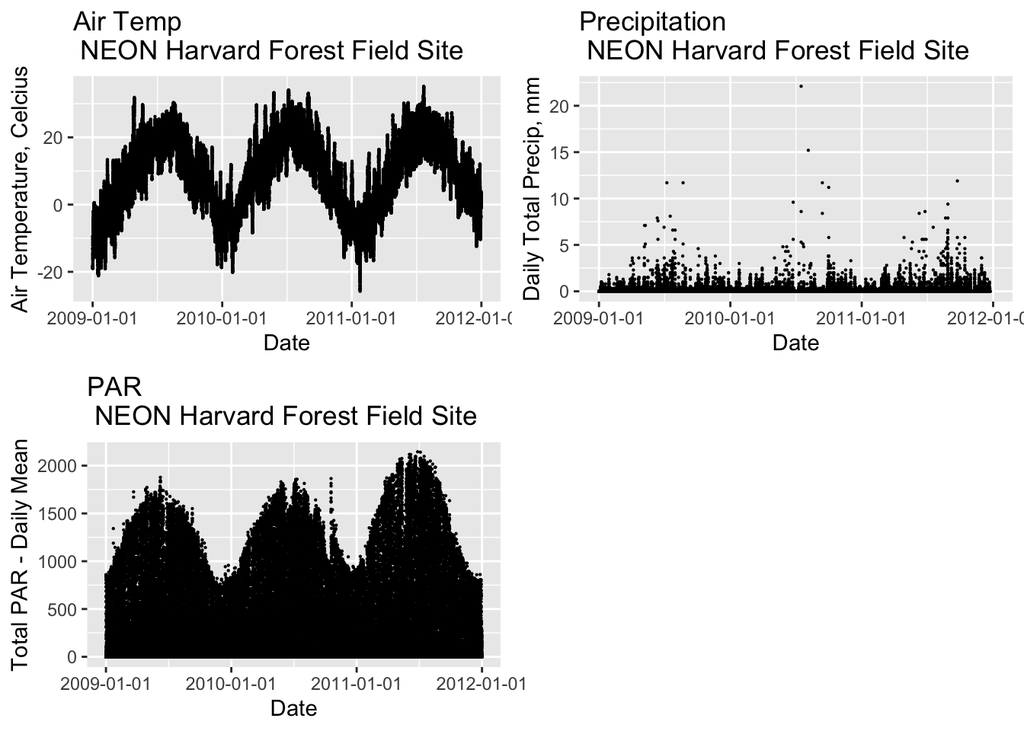

Daily Meteorological Conditions at Harvard Forest Between 2009 and 2011

However, summarizing the data at a coarser scale (e.g., daily, weekly, by season, or by year) may be easier to visually interpret during initial stages of data exploration.

### Extract Year from a Date-Time Column

To summarize by year efficiently, it is helpful to have a year column that we can use to `group` by. We can use the `lubridate` function `year()` to extract the year only from a `date-time` class R column.

```r
# create a year column
harMet15.09.11$year <- year(harMet15.09.11$datetime)
```

Using `names()` we see that we now have a `year` column in our `data_frame`.

```r
# check to make sure it worked
names(harMet15.09.11)
```

```
##  [1] "X"        "datetime" "jd"       "airt"     "f.airt"   "rh"
##  [7] "f.rh"     "dewp"     "f.dewp"   "prec"     "f.prec"   "slrr"
## [13] "f.slrr"   "parr"     "f.parr"   "netr"     "f.netr"   "bar"
## [19] "f.bar"    "wspd"     "f.wspd"   "wres"     "f.wres"   "wdir"
## [25] "f.wdir"   "wdev"     "f.wdev"   "gspd"     "f.gspd"   "s10t"
## [31] "f.s10t"   "year"
```

```r
str(harMet15.09.11$year)
```

```
##  num [1:105108] 2009 2009 2009 2009 2009 ...
```

Now that we have added a year column to our `data_frame`, we can use `dplyr` to summarize our data.

## Manipulate Data using dplyr

We will use `dplyr` functions `group_by` and `summarize` to perform these steps.

```r
# Create a group_by object using the year column
HARV.grp.year <- group_by(harMet15.09.11, # data_frame object
                          year) # column name to group by

# view class of the grouped object
class(HARV.grp.year)
```

```
## [1] "grouped_df" "tbl_df"     "tbl"        "data.frame"
```

The `group_by` function creates a “grouped” object. We can then use this grouped object to quickly calculate summary statistics by group - in this case, year. For example, we can count how many measurements were made each year using the `tally()` function. We can then use the `summarize` function to calculate the mean air temperature value each year. Note that “summarize” is a common function name across many different packages. If you happen to have two packages loaded at the same time that both have a “summarize” function, you may not get the results that you expect. Therefore, we will “disambiguate” our function by specifying which package it comes from using the double colon notation `dplyr::summarize()`.

```r
# how many measurements were made each year?
tally(HARV.grp.year)
```

```
## # A tibble: 3 x 2
##    year     n
##   <dbl> <int>
## 1  2009 35036
## 2  2010 35036
## 3  2011 35036
```

```r
# what is the mean airt value per year?
dplyr::summarize(HARV.grp.year,
          mean(airt)   # calculate the annual mean of airt
          )
```

```
## # A tibble: 3 x 2
##    year `mean(airt)`
##   <dbl>        <dbl>
## 1  2009        NA
## 2  2010        NA
## 3  2011         8.75
```

Why did this return a `NA` value for years 2009 and 2010? We know there are some values for both years. Let’s check our data for `NoData` values.

```r
# are there NoData values?
sum(is.na(HARV.grp.year$airt))
```

```
## [1] 2
```

```r
# where are the no data values
# just view the first 6 columns of data
HARV.grp.year[is.na(HARV.grp.year$airt),1:6]
```

```
## # A tibble: 2 x 6
##        X datetime               jd  airt f.airt    rh
##    <int> <dttm>              <int> <dbl> <chr>  <int>
## 1 158360 2009-07-08 14:15:00   189    NA M         NA
## 2 203173 2010-10-18 09:30:00   291    NA M         NA
```

It appears as if there are two `NoData` values (in 2009 and 2010) that are causing R to return a `NA` for the mean for those years. As we learned previously, we can use `na.rm` to tell R to ignore those values and calculate the final mean value.

```r
# calculate mean but remove NA values
dplyr::summarize(HARV.grp.year,
          mean(airt, na.rm = TRUE)
          )
```

```
## # A tibble: 3 x 2
##    year `mean(airt, na.rm = TRUE)`
##   <dbl>                      <dbl>
## 1  2009                       7.63
## 2  2010                       9.03
## 3  2011                       8.75
```

Great! We’ve now used the `group_by` function to create groups for each year of our data. We then calculated a summary mean value per year using `summarize`.

### dplyr Pipes

The above steps utilized several steps of R code and created 1 R object - `HARV.grp.year`. We can combine these steps using `pipes` in the `dplyr` package.

We can use `pipes` to string functions or processing steps together. The output of each step is fed directly into the next step using the syntax: `%>%`. This means we don’t need to save the output of each intermediate step as a new R object.

A few notes about piping syntax:

- A pipe begins with the object name that we will be manipulating, in our case `harMet15.09.11`.
- It then links that object with first manipulation step using `%>%`.
- Finally, the first function is called, in our case `group_by(year)`. Note that because we specified the object name in step one above, we can just use the column name

So, we have: `harMet15.09.11 %>% group_by(year)`

- We can then add an additional function (or more functions!) to our pipe. For example, we can tell R to `tally` or count the number of measurements per year.

`harMet15.09.11 %>% group_by(year) %>% tally()`

Let’s try it!

```r
# how many measurements were made a year?
harMet15.09.11 %>%
  group_by(year) %>%  # group by year
  tally() # count measurements per year
```

```
## # A tibble: 3 x 2
##    year     n
##   <dbl> <int>
## 1  2009 35036
## 2  2010 35036
## 3  2011 35036
```

Piping allows us to efficiently perform operations on our `data_frame` in that:

1. It allows us to condense our code, without naming intermediate steps.
2. The dplyr package is optimized to ensure fast processing!

We can use pipes to summarize data by year too:

```r
# what was the annual air temperature average
year.sum <- harMet15.09.11 %>%
  group_by(year) %>%  # group by year
  dplyr::summarize(mean(airt, na.rm=TRUE))

# what is the class of the output?
year.sum
```

```
## # A tibble: 3 x 2
##    year `mean(airt, na.rm = TRUE)`
##   <dbl>                      <dbl>
## 1  2009                       7.63
## 2  2010                       9.03
## 3  2011                       8.75
```

```r
# view structure of output
str(year.sum)
```

```
## tibble [3 × 2] (S3: tbl_df/tbl/data.frame)
##  $ year                    : num [1:3] 2009 2010 2011
##  $ mean(airt, na.rm = TRUE): num [1:3] 7.63 9.03 8.75
```

### Challenge: Using Pipes

Use piping to create a `data_frame` called `jday.avg` that contains the average `airt` per Julian day (`harMet15.09.11$jd`). Plot the output using `qplot`.

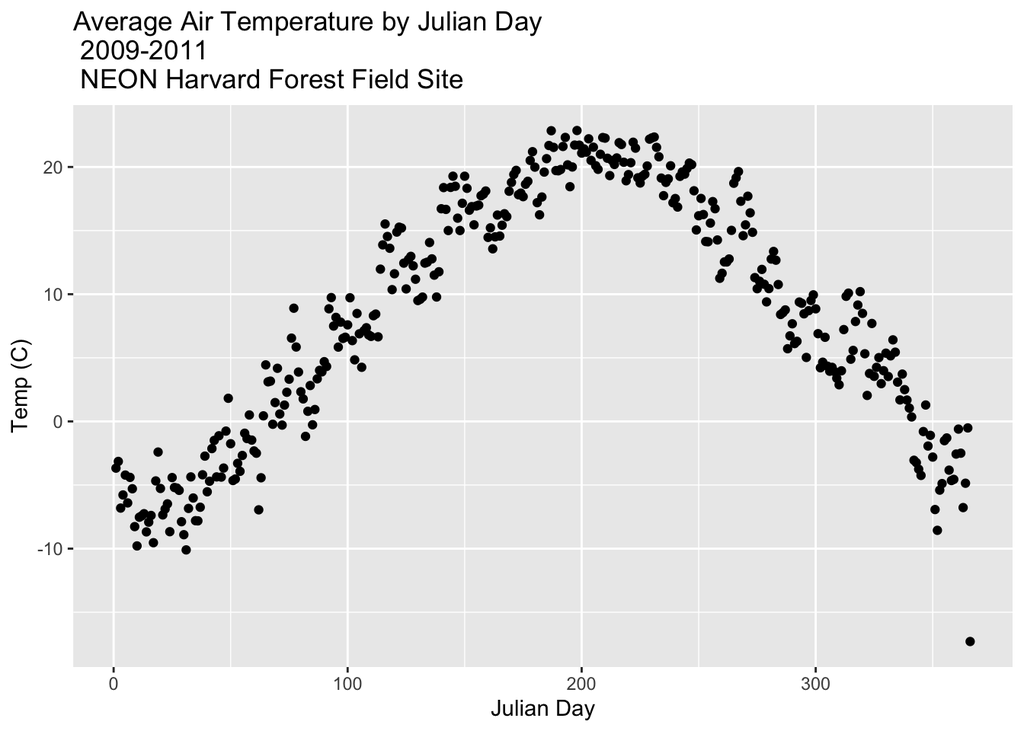

Average Temperature by Julian Date at Harvard Forest Between 2009 and 2011

**Data Tip:** Older `dplyr` versions used the `%.%` syntax to designate a pipe. Pipes are sometimes referred to as chains.

## Other dplyr Functions

`dplyr` works based on a series of *verb* functions that allow us to manipulate the data in different ways:

- `filter()` & `slice()`: filter rows based on values in specified columns
- `group-by()`: group all data by a column
- `arrange()`: sort data by values in specified columns
- `select()` & `rename()`: view and work with data from only specified columns
- `distinct()`: view and work with only unique values from specified columns
- `mutate()` & `transmute()`: add new data to a data frame
- `summarise()`: calculate the specified summary statistics
- `sample_n()` & `sample_frac()`: return a random sample of rows

(List modified from the CRAN `dplyr` [package description](https://cran.r-project.org/web/packages/dplyr/dplyr.pdf). )

The syntax for all `dplyr` functions is similar:

- the first argument is the target `data_frame`,
- the subsequent arguments dictate what to do with that `data_frame` and
- the output is a new data frame.

### Group by a Variable (or Two)

Our goal for this tutorial is to view drivers of annual phenology patterns. Specifically, we want to explore daily average temperature throughout the year. This means we need to calculate average temperature, for each day, across three years. To do this we can use the `group_by()` function as we did earlier. However this time, we can group by two variables: year and Julian Day (jd) as follows:

`group_by(year, jd)`

Let’s begin by counting or `tally`ing the total measurements per Julian day (or year day) using the `group_by()` function and pipes.

```r
harMet15.09.11 %>%         # use the harMet15.09.11 data_frame
  group_by(year, jd) %>%   # group data by Year & Julian day
  tally()                  # tally (count) observations per jd / year
```

```
## # A tibble: 1,096 x 3
## # Groups:   year [3]
##     year    jd     n
##    <dbl> <int> <int>
##  1  2009     1    96
##  2  2009     2    96
##  3  2009     3    96
##  4  2009     4    96
##  5  2009     5    96
##  6  2009     6    96
##  7  2009     7    96
##  8  2009     8    96
##  9  2009     9    96
## 10  2009    10    96
## # … with 1,086 more rows
```

The output shows we have 96 values for each day. Is that what we expect?

```r
24*4  # 24 hours/day * 4 15-min data points/hour
```

```
## [1] 96
```

**Data Tip:** If Julian days weren’t already in our data, we could use the `yday()` function from the `lubridate` package to create a new column containing Julian day values. More information in this [NEON Data Skills tutorial](https://www.neonscience.org/julian-day-conversion-r).

### Summarize by Group

We can use `summarize()` function to calculate a summary output value for each “group” - in this case Julian day per year. Let’s calculate the mean air temperature for each Julian day per year. Note that we are still using `na.rm=TRUE` to tell R to skip `NA` values.

```r
harMet15.09.11 %>%         # use the harMet15.09.11 data_frame
  group_by(year, jd) %>%   # group data by Year & Julian day
  dplyr::summarize(mean_airt = mean(airt, na.rm = TRUE))  # mean airtemp per jd / year
```

```
## # A tibble: 1,096 x 3
## # Groups:   year [3]
##     year    jd mean_airt
##    <dbl> <int>     <dbl>
##  1  2009     1    -15.1
##  2  2009     2     -9.14
##  3  2009     3     -5.54
##  4  2009     4     -6.35
##  5  2009     5     -2.41
##  6  2009     6     -4.92
##  7  2009     7     -2.59
##  8  2009     8     -3.23
##  9  2009     9     -9.92
## 10  2009    10    -11.1
## # … with 1,086 more rows
```

### Challenge: Summarization & Calculations with dplyr

We can use `sum` to calculate the total rather than mean value for each Julian Day. Using this information, do the following:

1. Calculate total `prec` for each Julian Day over the 3 years - name your data_frame `total.prec`.
2. Create a plot of Daily Total Precipitation for 2009-2011.
3. Add a title and x and y axis labels.
4. If you use `qplot` to create your plot, use `colour=as.factor(total.prec$year)` to color the data points by year.

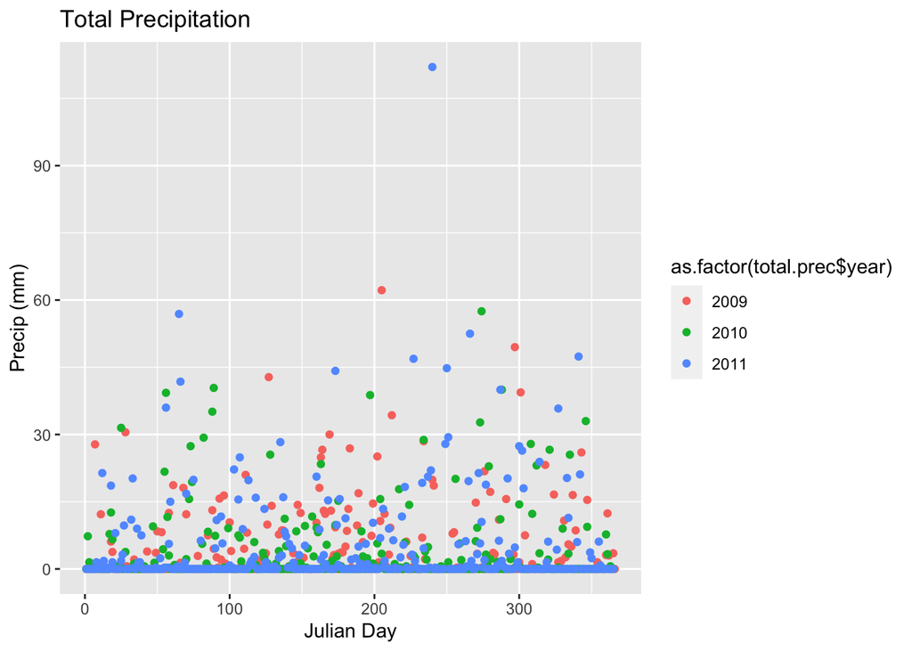

### Mutate - Add data_frame Columns to dplyr Output

We can use the `mutate()` function of `dplyr` to add additional columns of information to a data_frame. For instance, we added the year column independently at the very beginning of the tutorial. However, we can add the year using a `dplyr` pipe that also summarizes our data. To do this, we would use the syntax:

`mutate(year2 = year(datetime))`

year2 is the name of the column that will be added to the output `dplyr` data_frame.

```r
harMet15.09.11 %>%
  mutate(year2 = year(datetime)) %>%
  group_by(year2, jd) %>%
  dplyr::summarize(mean_airt = mean(airt, na.rm = TRUE))
```

```
## # A tibble: 1,096 x 3
## # Groups:   year2 [3]
##    year2    jd mean_airt
##    <dbl> <int>     <dbl>
##  1  2009     1    -15.1
##  2  2009     2     -9.14
##  3  2009     3     -5.54
##  4  2009     4     -6.35
##  5  2009     5     -2.41
##  6  2009     6     -4.92
##  7  2009     7     -2.59
##  8  2009     8     -3.23
##  9  2009     9     -9.92
## 10  2009    10    -11.1
## # … with 1,086 more rows
```

**Data Tip:** The `mutate` function is similar to `transform()` in base R. However,`mutate()` allows us to create and immediately use the variable (`year2`).

## Save dplyr Output as data_frame

We can save output from a `dplyr` pipe as a new R object to use for quick plotting.

```r
harTemp.daily.09.11<-harMet15.09.11 %>%
                    mutate(year2 = year(datetime)) %>%
                    group_by(year2, jd) %>%
                    dplyr::summarize(mean_airt = mean(airt, na.rm = TRUE))

head(harTemp.daily.09.11)
```

```
## # A tibble: 6 x 3
## # Groups:   year2 [1]
##   year2    jd mean_airt
##   <dbl> <int>     <dbl>
## 1  2009     1    -15.1
## 2  2009     2     -9.14
## 3  2009     3     -5.54
## 4  2009     4     -6.35
## 5  2009     5     -2.41
## 6  2009     6     -4.92
```

### Add Date-Time To dplyr Output

In the challenge above, we created a plot of daily precipitation data using `qplot`. However, the x-axis ranged from 0-366 (Julian Days for the year). It would have been easier to create a meaningful plot across all three years if we had a continuous date variable in our `data_frame` representing the year and date for each summary value.

We can add the the `datetime` column value to our `data_frame` by adding an additional argument to the `summarize()` function. In this case, we will add the `first` datetime value that R encounters when summarizing data by group as follows:

`datetime = first(datetime)`

Our new summarize statement in our pipe will look like this:

`summarize(mean_airt = mean(airt, na.rm = TRUE), datetime = first(datetime))`

Let’s try it!

```r
# add in a datatime column
harTemp.daily.09.11 <- harMet15.09.11 %>%
  mutate(year3 = year(datetime)) %>%
  group_by(year3, jd) %>%
  dplyr::summarize(mean_airt = mean(airt, na.rm = TRUE), datetime = first(datetime))

# view str and head of data
str(harTemp.daily.09.11)
```

```
## tibble [1,096 × 4] (S3: grouped_df/tbl_df/tbl/data.frame)
##  $ year3    : num [1:1096] 2009 2009 2009 2009 2009 ...
##  $ jd       : int [1:1096] 1 2 3 4 5 6 7 8 9 10 ...
##  $ mean_airt: num [1:1096] -15.13 -9.14 -5.54 -6.35 -2.41 ...
##  $ datetime : POSIXct[1:1096], format: "2009-01-01 00:15:00" "2009-01-02 00:15:00" ...
##  - attr(*, "groups")= tibble [3 × 2] (S3: tbl_df/tbl/data.frame)
##   ..$ year3: num [1:3] 2009 2010 2011
##   ..$ .rows:List of 3
##   .. ..$ : int [1:366] 1 2 3 4 5 6 7 8 9 10 ...
##   .. ..$ : int [1:365] 367 368 369 370 371 372 373 374 375 376 ...
##   .. ..$ : int [1:365] 732 733 734 735 736 737 738 739 740 741 ...
##   ..- attr(*, ".drop")= logi TRUE
```

```r
head(harTemp.daily.09.11)
```

```
## # A tibble: 6 x 4
## # Groups:   year3 [1]
##   year3    jd mean_airt datetime
##   <dbl> <int>     <dbl> <dttm>
## 1  2009     1    -15.1  2009-01-01 00:15:00
## 2  2009     2     -9.14 2009-01-02 00:15:00
## 3  2009     3     -5.54 2009-01-03 00:15:00
## 4  2009     4     -6.35 2009-01-04 00:15:00
## 5  2009     5     -2.41 2009-01-05 00:15:00
## 6  2009     6     -4.92 2009-01-06 00:15:00
```

### Challenge: Combined dplyr Skills

1. Plot daily total precipitation from 2009-2011 as we did in the previous challenge. However this time, use the new syntax that you learned (mutate and summarize to add a datetime column to your output data_frame).
2. Create a data_frame of the average *monthly* air temperature for 2009-2011. Name the new data frame `harTemp.monthly.09.11`. Plot your output.

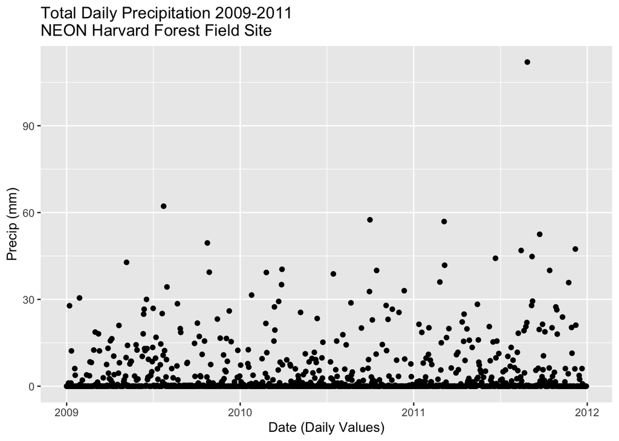

Daily Precipitation at Harvard Forest Between 2009 and 2011

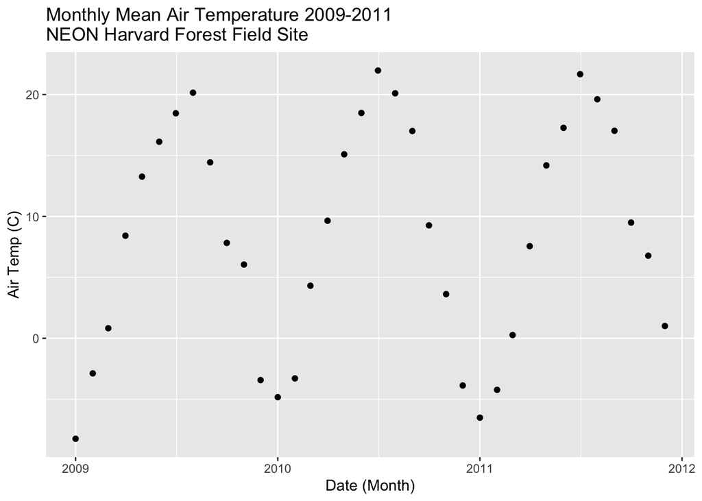

Monthly Mean Temperature at Harvard Forest Between 2009 and 2011